# R02 Group Comparison

Marco Kühne

01 April 2022

# Instructions

Please create a R markdown script and name it `R02_name.Rmd` replacing `name` by your name. Follow the structure of this document. Start each section with the appropriate heading by using a hashtag as first symbol (i.e. go for *Data Preparation*, then *Load data*, etc.). When you are done, knit your document in order to create a HTML file. Name it `R02_name.html` replacing name by your name.

The final `R02_name.html` document is supposed to show code and its result. Optimally, it should hide warnings and messages. Make it clean and concise.

# Learning Goals

- Calculate and compare the average years of education of men and women.
- Data: SOEP practice data.
- Visualization: Boxplot.

# Data Preparation

### Load data (1 pt)

Please download the SOEP practice data and store it as `soep`. The source file is this zip file `"https://www.diw.de/documents/dokumentenarchiv/17/diw_01.c.412698.de/soep_lebensz_en.zip"`. First, unzip this file with the `unz()` command, and wrap the result inside of the `read_dta()` function from the `haven` package (nesting). The procedure is described here: https://rpubs.com/otienodominic/398952.

### Inspect the data (1 pt)

Use the `datatable()` command from the `DT` package on `soep` to inspect the data.

The result shoule look like this:

|  | id | year | sex | education | no_kids | health_org | satisf_org | health_std | satisf_std |
| --- | --- | --- | --- | --- | --- | --- | --- | --- | --- |
| 1 | 312 | 2004 | 1 |  | 1 | 4 | 7 | 0.567010283470154 | -0.0909090936183929 |
| 2 | 399 | 2000 | 0 | 12 | 1 | 4 | 8 | 0.567010283470154 | 0.477272719144821 |
| 3 | 399 | 2001 | 0 | 12 | 1 | 4 | 9 | 0.567010283470154 | 1.04545450210571 |
| 4 | 457 | 2000 | 0 | 18 | 0 | 3 | 8 | -0.463917523622513 | 0.477272719144821 |
| 5 | 457 | 2002 | 0 | 18 | 0 | 3 | 7 | -0.463917523622513 | -0.0909090936183929 |
| 6 | 457 | 2004 | 0 | 18 | 0 | 2 | 4 | -1.49484539031982 | -1.79545450210571 |
| 7 | 748 | 2000 | 1 | 14 | 0 | 3 | 5 | -0.463917523622513 | -1.22727274894714 |
| 8 | 761 | 2000 | 1 | 16 | 2 | 3 | 7 | -0.463917523622513 | -0.0909090936183929 |
| 9 | 761 | 2001 | 1 | 16 | 2 | 3 | 7 | -0.463917523622513 | -0.0909090936183929 |
| 10 | 1044 | 2000 | 0 | 14 | 1 | 4 | 5 | 0.567010283470154 | -1.22727274894714 |

[output cut: 12912 more lines]

Sort the variables `education`, `no_kids` or `health_org`. Notice that there are empty cells.

### Missing data (1 pt)

Please remove all missing data (so called complete case analysis). This can be done via the `complete.cases()` function and many more alternatives. Store the result as `soep_no_na`. The sample size is reduced from 12922 observations (full sample) to 10659 observations (without `NA`). The number of rows can be checked with `nrow(soep_no_na)`.

### Subsample (1 pt)

Create a subsample (a.k.a. subset) of people with no children in the household and call it `nokids`. Hint: There are 6690 observations expected.

# Data Exploration

## Psycho summary (1 pt)

The result should be:

```
##            vars    n    mean   sd  min  max range   se
## year          1 6690 2001.75 1.44 2000 2004     4 0.02
## sex           2 6690    0.54 0.50    0    1     1 0.01
## education     3 6690   11.76 2.43    7   18    11 0.03
## health_org    4 6690    3.32 0.99    1    5     4 0.01
## satisf_org    5 6690    7.16 1.79    0   10    10 0.02
```

What does the mean of the variable `sex` indicate?

## Great grouped tables (1 pt)

Please use `tbl_summary()` from the `gtsummary` package on the selection of variables from `nokids` data. The option `include = c(A, B, C)` allows to select variables inside the `tbl_summary()`, so that the data frame `nokids` is unchanged. The option `by` allows grouping. Hint: More information on the command can be found in the corresponding vignette https://cran.r-project.org/web/packages/gtsummary/vignettes/tbl_summary.html.

The result should be:

| **Characteristic** | **0**, N = 3,109<sup>1</sup> | **1**, N = 3,581<sup>1</sup> |
| --- | --- | --- |
| census year |  |  |
| 2000 | 858 (28%) | 961 (27%) |
| 2001 | 649 (21%) | 737 (21%) |
| 2002 | 569 (18%) | 669 (19%) |
| 2003 | 523 (17%) | 613 (17%) |
| 2004 | 510 (16%) | 601 (17%) |
| number of years of education | 11.00 (10.50, 13.00) | 11.00 (10.50, 12.00) |
| current health |  |  |
| 1 | 127 (4.1%) | 182 (5.1%) |
| 2 | 413 (13%) | 589 (16%) |
| 3 | 1,031 (33%) | 1,251 (35%) |
| 4 | 1,216 (39%) | 1,227 (34%) |
| 5 | 322 (10%) | 332 (9.3%) |
| satisfaction with life as today | 7.00 (6.00, 8.00) | 7.00 (6.00, 8.00) |

<sup>*1*</sup> n (%); Median (IQR)

Why did `tbl_summary` gives the exact count of values for `year` and `health_org` but not for `education` and `satisf_org`? Note that year by year there are fewer observations.

## Furious with factors (1 pt)

First, filter `soep_no_na` for the `year` 2000 and store it as `soep_2000` (number of observations is 3000).

```r
soep_2000 <- subset(soep_no_na, year == 2000)
```

Create a new variable `sex_factor` in the `soep_2000` data by applying `as.factor()` to the `sex` variable. Then, define `levels(soep_2000$sex_factor)` as the character vector `c("male", "female")`. Print `summary(soep_2000$sex_factor)`.

## Mean per group (1 pt)

Please calculate the mean of `education` for men and women with the `by()` command and store them as `edu_means`. Print `edu_means`. `by()` takes three inputs. First, the data to be calculated (`education` as a variable in `soep_2000`), the factor or group *by* which the calculation should be splitted and finally a function, here the `mean`.

## Grouped boxplot (1 pt)

Create a boxplot of years of `education` grouped by `sex_factor` (gender).[^1] A **boxplot** is a method for graphically depicting groups of numerical data through their quartiles. It shows 50% of the data in a box and the median in the middle of the box and whiskers outside of the box. Replicate the following figure. This can be done with `boxplot()` function from base R `geom_boxplot()` function from `ggplot2` package. The labels (title, subtitle, axis) should be identical.

Challenge: Add the mean of the groups to the boxplot (as red bold point or something similar).

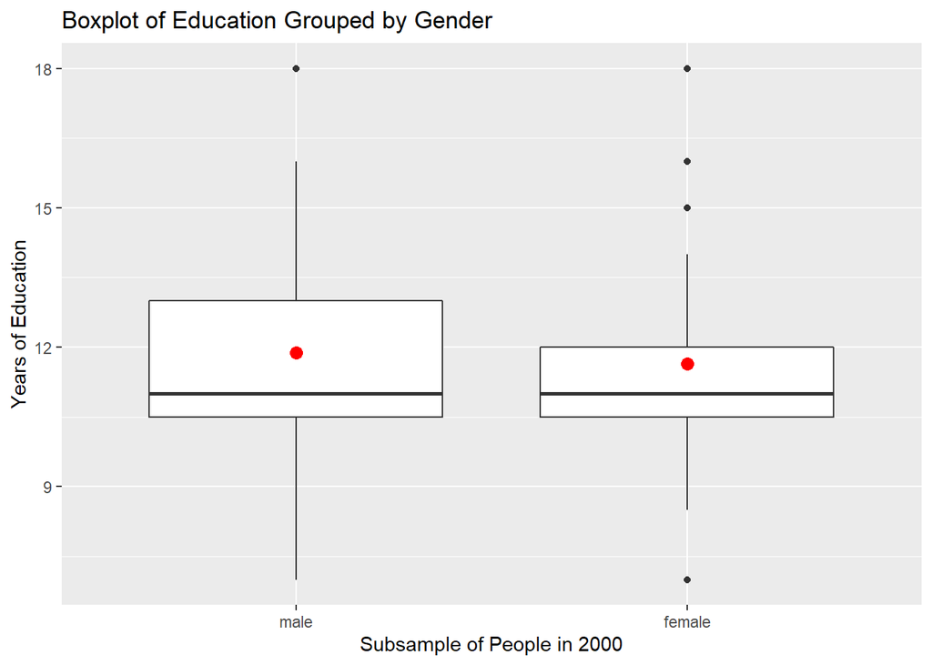

The two boxplots look very similar. In both groups the mean is higher than the median. This is an indication that the distribution of education is **skewed** to the right.

# YaRrr! The Pirate’s Quiz (1 pt)

*YaRrr! The Pirate’s Guide to R* is an ebook in bookdown format to help you learn R from the ground-up. In chapter [9.1. workspace management functions](https://bookdown.org/ndphillips/YaRrr/workspace-management-functions.html) there is a picture of a pirate. Contrary to good academic practice, there is no source of the picture given.

**Danger? I look on the wild side. I laugh in the face of danger! Show me the PiRate!**

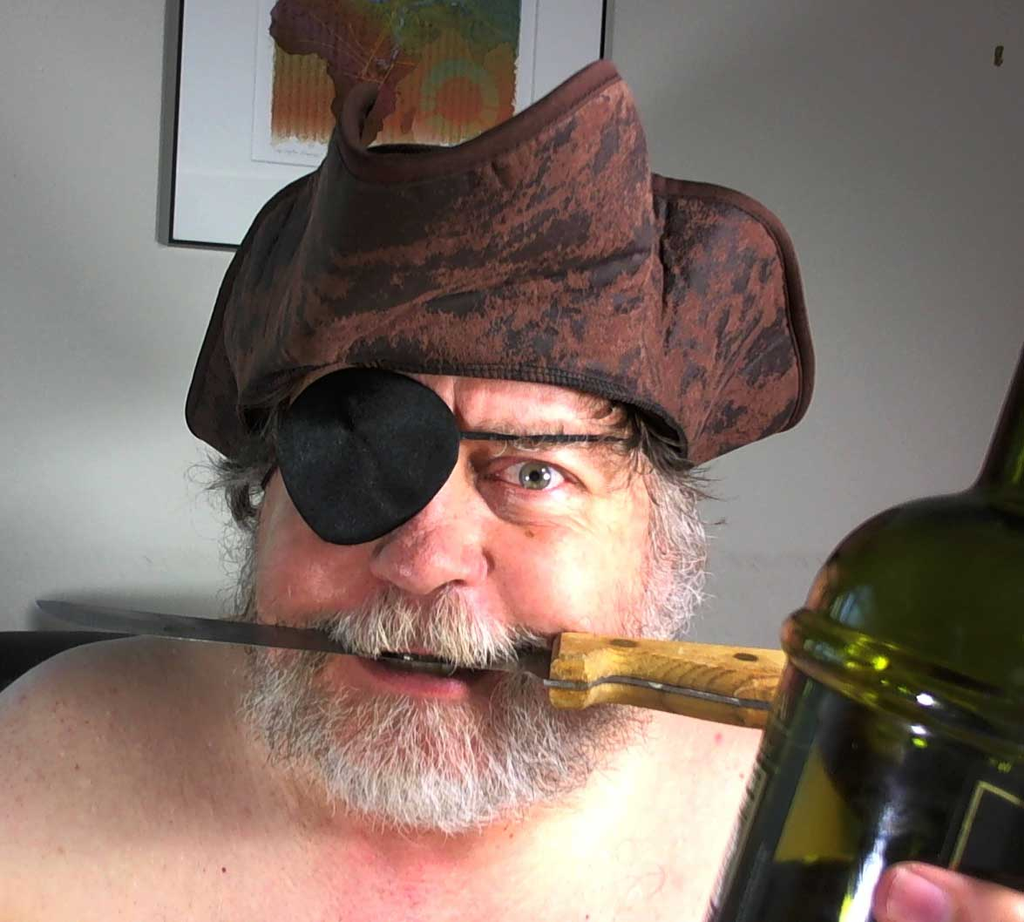

Figure 2: Who’s that boy?

This pirate is not a random, no-name pirate. On the contrary, he has a Wikipedia article in several languages. Who is he?

[^1]: Test what happens when you use `sex` instead.